# Who votes for the Liberal Party and who votes for Conservative Party in Canada?

Wijdan Tariq

2020-09-27

```
## TO CITE THIS SURVEY FILE:
##
## - Stephenson, Laura B; Harell, Allison; Rubenson, Daniel; Loewen, Peter John, 2020, '2019 Canadian Election Study - Online Survey', https://doi.org/10.7910/DVN/DUS88V, Harvard Dataverse, V1
##
## - Stephenson, Laura, Allison Harrel, Daniel Rubenson and Peter Loewen. Forthcoming. 'Measuring Preferences and Behaviour in the 2019 Canadian Election Study,' Canadian Journal of Political Science.
##
## LINK: https://dataverse.harvard.edu/dataset.xhtml?persistentId=doi:10.7910/DVN/DUS88V
```

# Abstract

The Liberal Party and the Conservative Party are the two parties that dominated Canadian politics since the country’s founding. In this paper, I explore survey data from the Canadian Election Study to better understand why Canadians vote for each party. My findings suggest that Canadians decide which party to vote for based on their views on decisive questions on topics such as the environment, education, defence, and immigration. The study has implications for people who are interested in understanding the factors that influence Canadian voter behavior.

# Introduction

# Data

The data was obtained from the online survey data of the Canadian Election Study 2019 (Stephenson et al., 2020; Stephenson et al., forthcoming) using an R Package created by Hodgetts and Alexander (2020). The online survey was conducted during the Canadian Federal Election campaign period. The elections took place on October 21, 2019 and the survey collection period as September 13 to October 21. As such, answers of voters to the question of which party they would vote for would be quite representative of the final election outcome. Data was collected from 37,822 people, including non-citizens. I filtered the data by citizens only, since permanent residents are not eligible to vote. Furthermore, I limited my analysis to voters who responded “Liberal Party” or “Conservative Party” to the question of which party they are most likely to cast their vote for. This is in order to make the analysis more manageable, but also because these are the two parties that have always dominated the Canadian political scene including in the 2019 elections.

The first table shows aggregate data on the number of voters in the sample for each party.

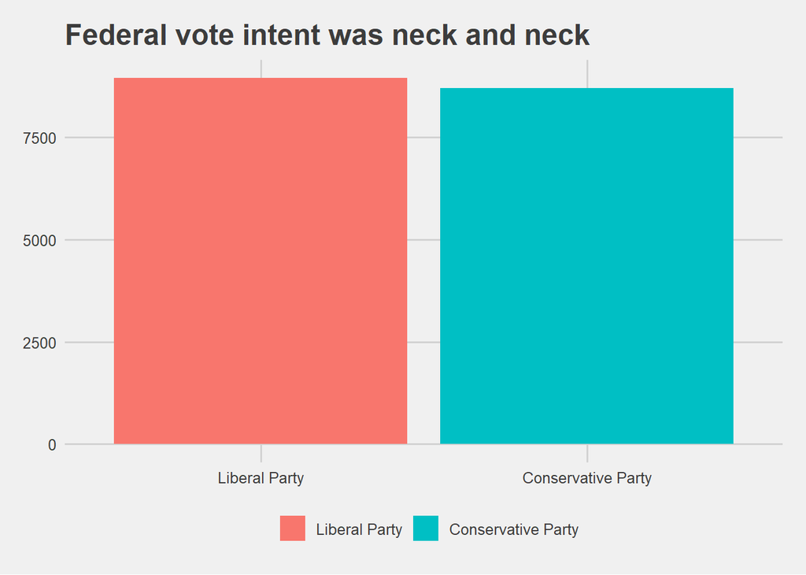

Number of votes for each party.

Interestingly, the two party voters have very similar age demographics. On the other hand, there seems to be a trend in income categories. More lower income voters tend to vote for the Liberal Party whilst more higher income voters tend to vote for the Conservative Party. Of those who did not disclose their households incomes, about 53% would vote Conservative and about 47% would vote Liberal.

Descriptive Statistics for Voter Age

| Voter Choice | n | Q1 | Median | Mean | Q3 | St. Dev |
| --- | --- | --- | --- | --- | --- | --- |
| Liberal Party | 8949 | 36 | 51 | 50.08884 | 64 | 16.70626 |
| Conservative Party | 8713 | 39 | 53 | 51.56203 | 64 | 16.01937 |

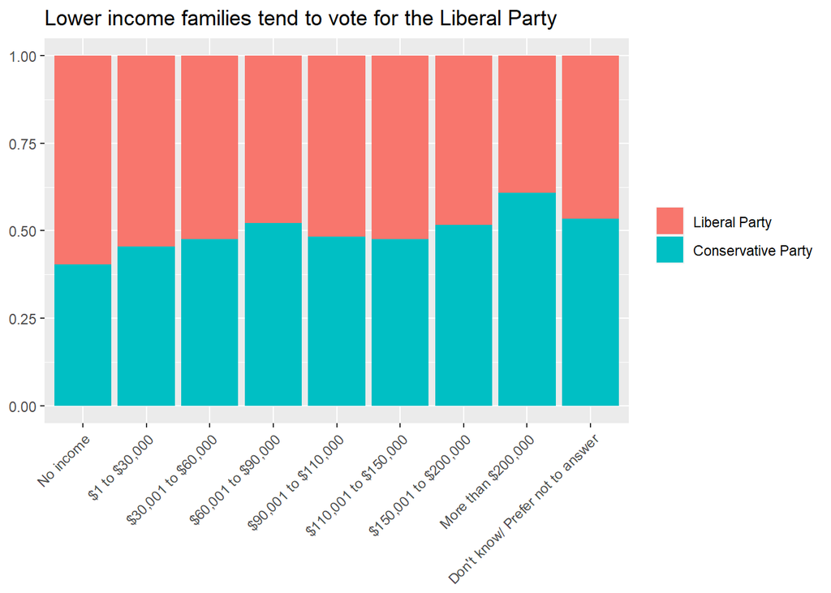

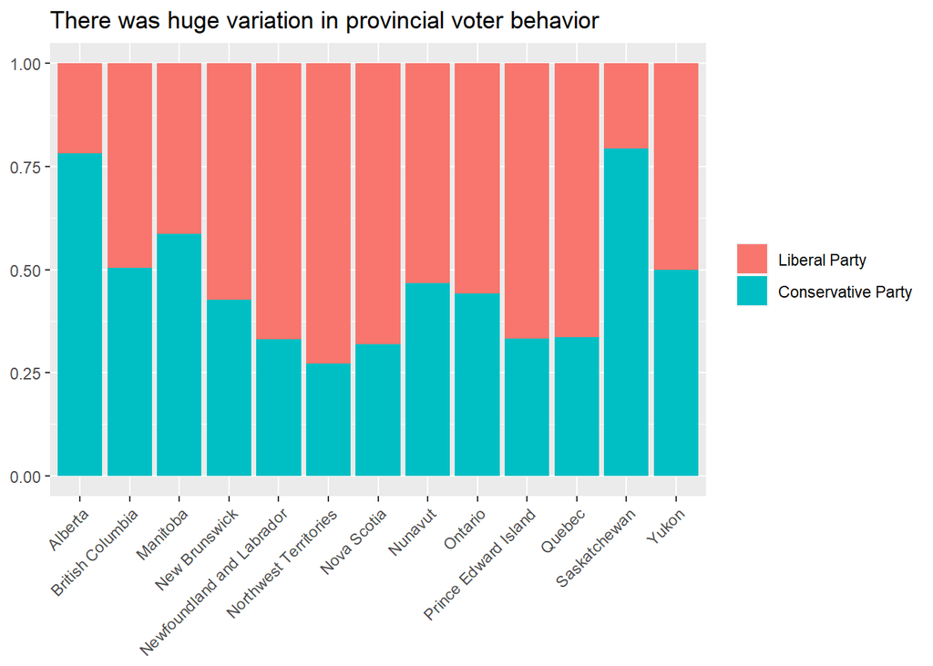

University degree holders tend to vote for the Liberal Party. Notice that a higher percentage of people who did not disclose their level of education were likely to vote for the Conservative Party.

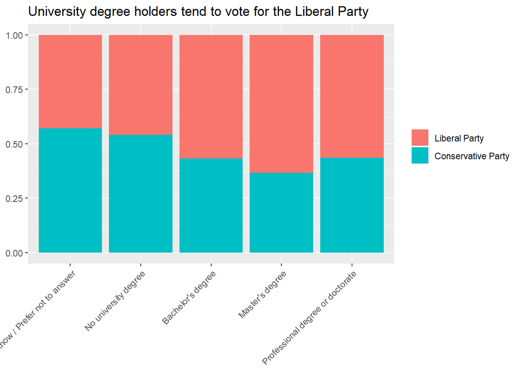

Perhaps the most decisive factor of all was the answer to the question “Thinking about government spending, should the federal government spend more, less, or about the same as now on the following areas?”. The areas included education, the environment, justice & law, defence, and immigrant & minorities. The following tables show that the answer to these questions is strongly associated with the voter’s party choice.

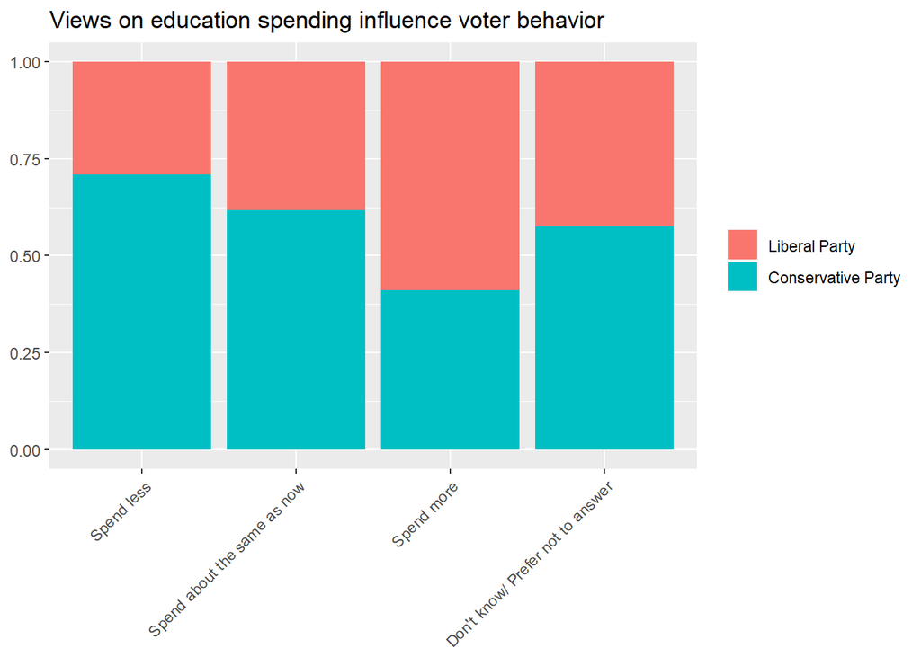

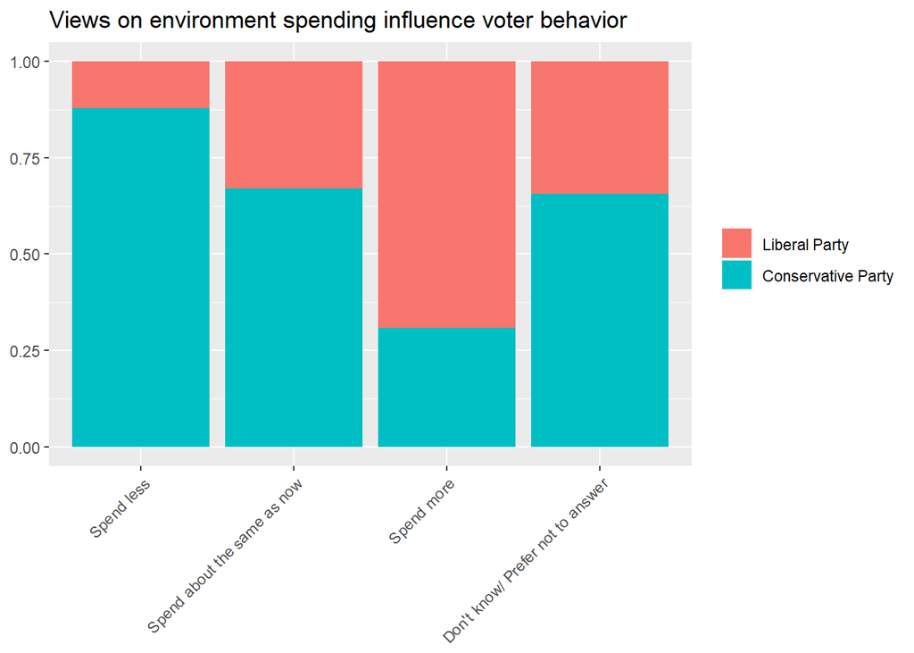

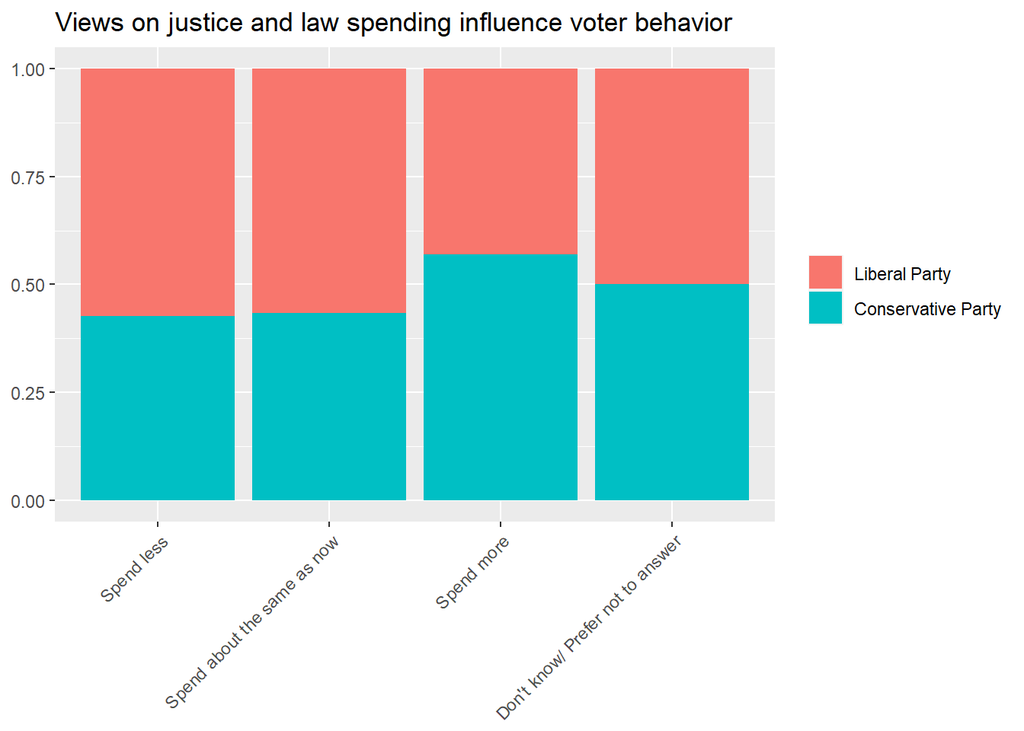

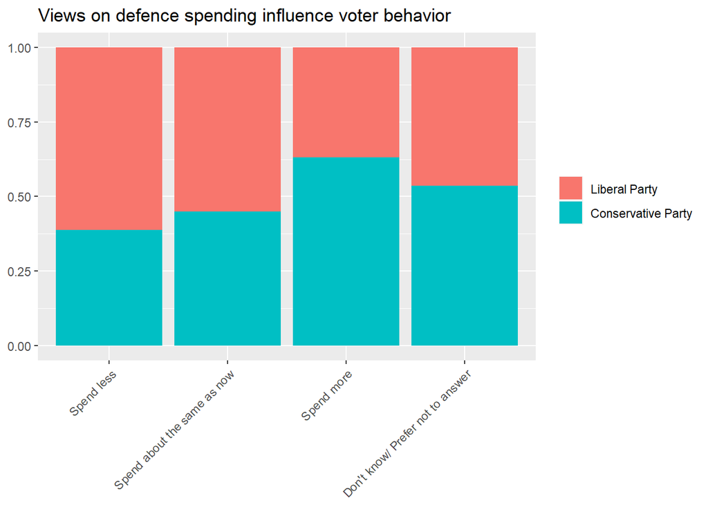

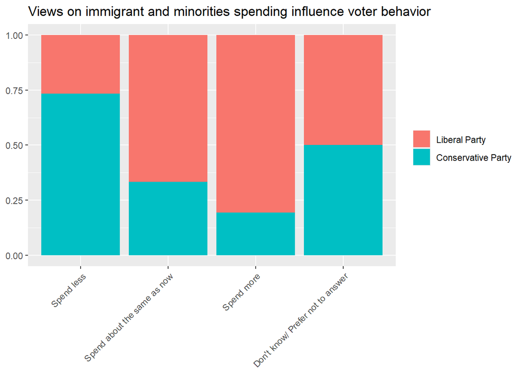

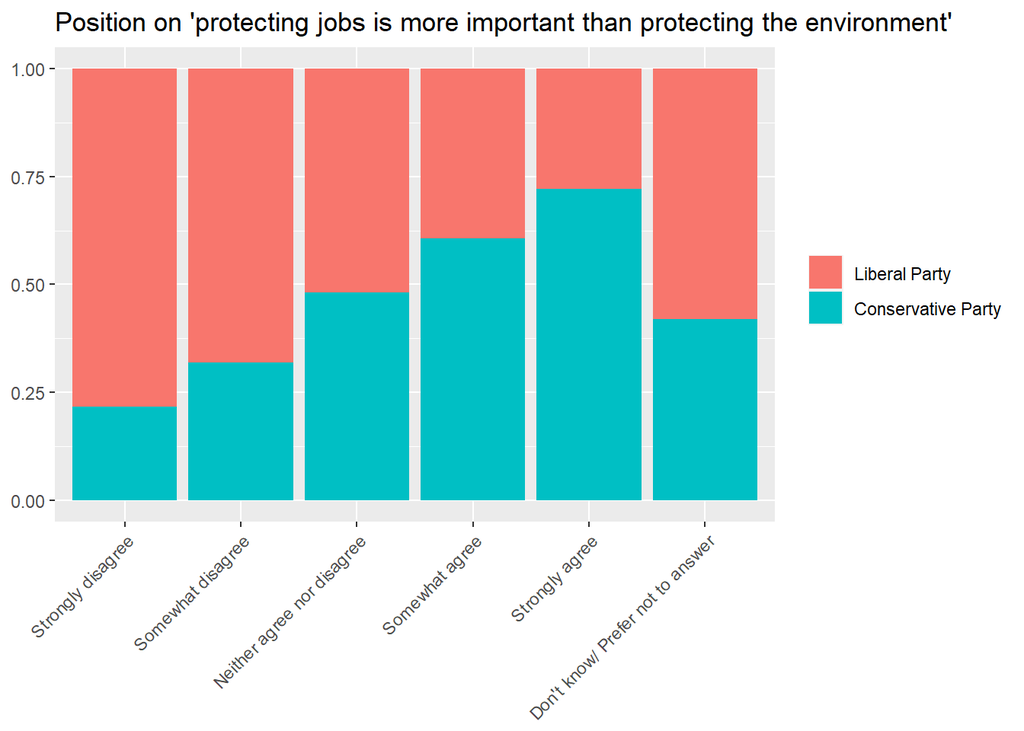

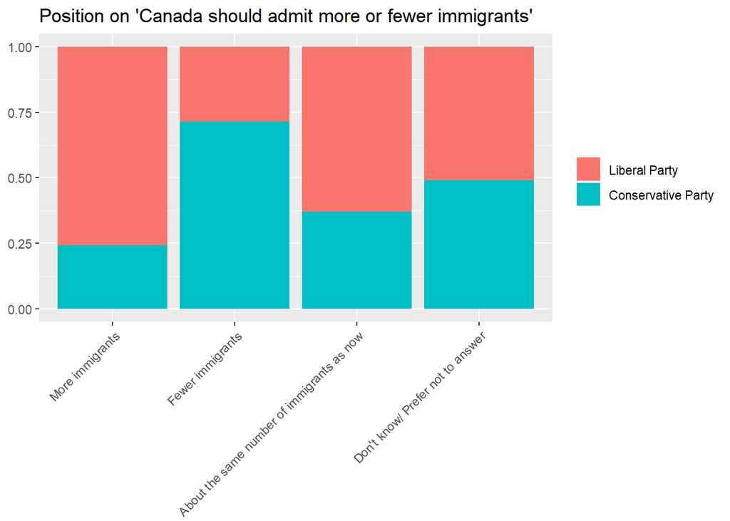

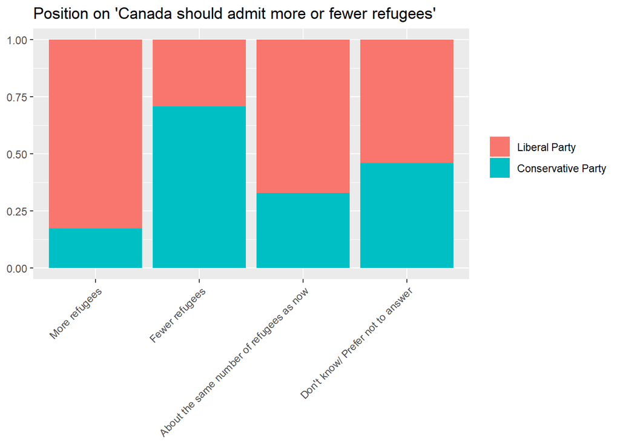

# Next steps

It is important to simultaneously control for the multiple factors that may affect voter behavior in order to address the issue of confounding variables. Statistical models such as the multiple regression model do just that. More specifically, the logistic regression model could be utilized to generate the probability that a voter would vote for Liberal or Conservative depending on the factors discussed in this paper. Moreoever, the regression model would also be able estimate the impact of each factor on the likelihood of the party vote.

It is important to mention that I did not take into account a few other important variables. Economic perceptions which have been shown to have a significant impact on votes (Lewis-Beck, Nadeau, and Elias; 2008). As such, this might be an important confounding variable that should be included in any future analysis.

# References

Hodgetts, Paul and Rohan Alexander (2020). cesR: Access the CES Datasets a Little Easier.. R package version 0.1.0.

Jeffrey B. Arnold (2019). ggthemes: Extra Themes, Scales and Geoms for ‘ggplot2’. R package version 4.2.0. https://CRAN.R-project.org/package=ggthemes

Lewis‐Beck, M. S., Nadeau, R., & Elias, A. (2008). Economics, party, and the vote: Causality issues and panel data. *American Journal of Political Science*, 52(1), 84-95.

Richard Iannone, Joe Cheng and Barret Schloerke (2020). gt: Easily Create Presentation-Ready Display Tables. R package version 0.2.2. https://CRAN.R-project.org/package=gt

Stephenson, Laura B; Harell, Allison; Rubenson, Daniel; Loewen, Peter John, 2020, ‘2019 Canadian Election Study - Online Survey’, https://doi.org/10.7910/DVN/DUS88V, Harvard Dataverse, V1

Stephenson, Laura, Allison Harrel, Daniel Rubenson and Peter Loewen. Forthcoming. ‘Measuring Preferences and Behaviour in the 2019 Canadian Election Study,’ *Canadian Journal of Political Science*.

Wickham et al., (2020). devtools: Tools to Make Developing R Packages Easier. R package version 2.3.2. https://CRAN.R-project.org/package=devtools

Wickham et al., (2019). Welcome to the tidyverse. Journal of Open Source Software, 4(43), 1686, https://doi.org/10.21105/joss.01686